# NetAct Package User’s Guide

Kenong Su and Mingyang Lv

Department of Biostatistics, Epidemiology and Informatics @ UPenn  
Bioengineering Department @ Northeastern

suke@upenn.edu

2 February 2022

#### Abstract

Inference of TF-gene regulatory network based activities, **`NetAct`** is a purely data-driven approach for calculating transcript regulatory network. The inferred TF-gene effects can be obtained from a comprehensive database which is curated by using a machine learning strategy.

#### Package

NetAct 0.0.99

# 1 Installation and help

## 1.1 Install NetAct

To install this package, start R (version > “4.1”) and enter:

```r
if(!requireNamespace("BiocManager", quietly = TRUE))
    install.packages("BiocManager")
BiocManager::install("NetAct")
install_github("suke18/NetAct", dependencies=T, build_vignettes = T)
```

## 1.2 Including sample data

We used GSE17708 (Sartor et al. 2010) lung adenocarcinoma gene expression data to infer TGF-beta-induced epithelial-mesenchymal transition (EMT). The data can be accessed and processed by using **GEOquery** and **affy** Bioconductor packages. The standard pipeline for querying GEO dataset is listed below. One can also directly load the raw data.

```r
rm(list = ls())
library("GEOquery")
library("affy")
accessionID="GSE17708"
geo=getGEO(accessionID)[[1]]
pd=pData(geo)
filePaths = getGEOSuppFiles(accessionID)
system(paste("tar xvf", sprintf("%s/%s_RAW.tar", accessionID, accessionID)))
dat=ReadAffy(filenames=basename(as.character(pd$supplementary_file)),phenoData=pd)
eset = rma(dat)
edata = exprs(eset)
sample_names = c (paste("Un",seq(1, 3),sep=""),
                  paste("0.5h",seq(1, 3),sep=""),
                  paste("1h",seq(1, 3),sep=""),
                  paste("2h",seq(1, 2),sep=""),
                  paste("4h",seq(1, 3),sep=""),
                  paste("8h",seq(1, 3),sep=""),
                  paste("16h",seq(1, 3),sep=""),
                  paste("24h",seq(1, 3),sep=""),
                  paste("72h",seq(1, 3),sep=""))
colnames(edata) = sample_names
```

## 1.3 process the data

It is important to look at the distributions. Also, we match the probe identifiers to the gene names by using **hgu133plus2.db** library.

```r
boxplot(edata)
edata = as.data.frame(edata)
library("hgu133plus2.db")
x = hgu133plus2SYMBOL
# Get the probe identifiers that are mapped to a gene symbol
mapped_probes = mappedkeys(x)
# Convert to a list
xx = as.list(x[mapped_probes])
mapped_genes = lapply(rownames(edata), function(x) xx[[x]])
mapped_genes[sapply(mapped_genes, is.null)] = NA
mapped_genes = unlist(mapped_genes)
edata$Symbol = mapped_genes
edata = edata[!is.na(edata[,"Symbol"]),]   # remove unannotated genes
edata = aggregate(. ~ Symbol, edata, mean)  # mean expression for redudant probes
rownames(edata) = edata[,"Symbol"]
edata$Symbol = NULL
```

## 1.4 curate the ExpressionSet object.

save the data into the standard ExpressionSet object.

```r
celltype = c (rep("Early", each=9), rep("Middle", each=8), rep("Late", each=9))
names(celltype) = sample_names
phenoData = new("AnnotatedDataFrame", data = data.frame(celltype = factor(celltype)))
rownames(phenoData) = colnames(edata)
neweset = ExpressionSet(assayData = as.matrix(edata), phenoData = phenoData)
save(neweset, file = "EMT.Rdata")
```

# 2 Step-by-step in NetAct

## 2.1 call DE genes

```r
library(NetAct)
data("hDB")
data("EMT")
compare_list = c("Early-Middle", "Middle-Late", "Early-Late")
DErslt = MicroProcess(neweset, compare_list)
```

## 2.2 highlight the significantly enriched TFs

Firstly, we curated a comprehensive TF-gene database based on both literature-based and computation-based databases including TRRUST (Han et al. 2015), RegNetwork (Liu et al. 2015), tfacts (http://www.tfacts.org/), and TRED (Zhao et al. 2005) We utilized; and ChEA, TRANSFAC, JASPAR, and ENCODE. We utilized knock-down or knock-out experiments to verify the regulatory effects. The underlying assumption is that, with a better TF-target database, GSEA will be more likely to detect the corresponding perturbed TFs

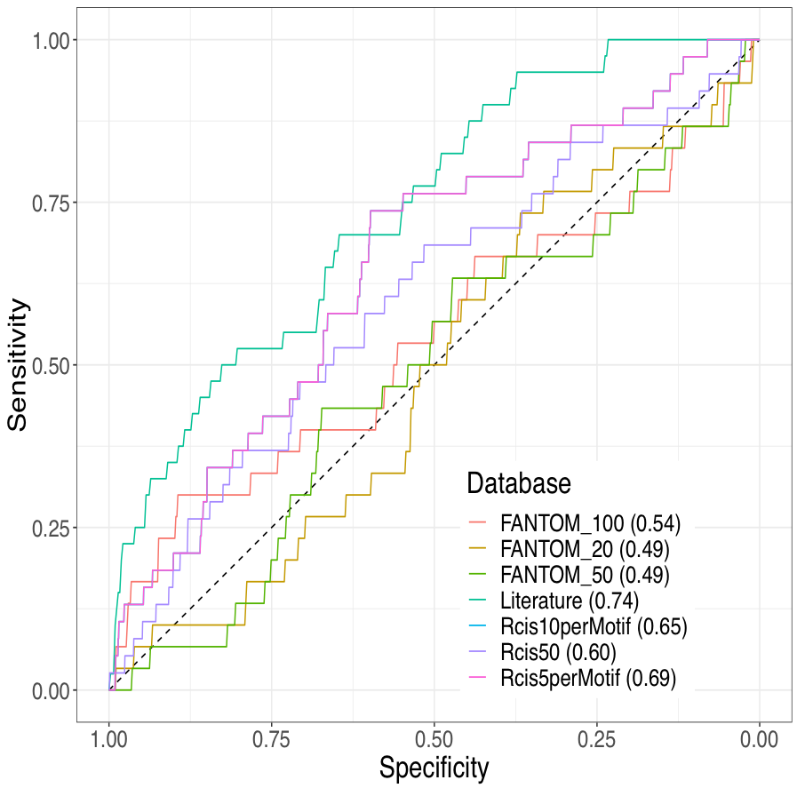

.

Secondly, we adopt the permutation approach to select the significantly enriched TFs by using GSEA algorithm. This is implemented in the *`TF_GSEA`* function, where the core is coded in C++ style. A similar idea is shown in fgsea bioconductor however the permutation is asymptotic not that accurate.

```r
gsearslt_1 = TF_GSEA(hDB, DErslt$`Early-Middle`, minSize=8, nperm = 10000, qval = T)
#gsearslt_2 = TF_GSEA(hDB, DErslt$`Middle-Late`, minSize=8, nperm = 10000, qval = T)
#gsearslt_3 = TF_GSEA(hDB, DErslt$`Early-Late`, minSize=8, nperm = 10000, qval = T)
```

The results (gsearslt_1, gsearslt_2, and gsearslt_3) are stored in corresponding csv files (results_v3_1.csv, results_v3_2.csv, and results_v3_3.csv).

## 2.3 aggregate the TF lists

Since we obtain a table for each comparison, we aggregate the results from multiple comparisons by considering the q value cutoff and coverage of the database. In this results, we identify important genes such as *BRCA1*, *EGR1*, *JUN*, *HOXB7*, *TP53*, *TWIST1*, *ZEB1*, and etc.

```r
gsearslt_1 = read.csv("vignettes/results_v3_1.csv")
gsearslt_2 = read.csv("vignettes/results_v3_2.csv")
gsearslt_3 = read.csv("vignettes/results_v3_3.csv")
gsearslts = list(gsearslt_1, gsearslt_2, gsearslt_3)
tfs = TF_Selection(gsearslts, qval = 0.01, compList = compare_list, ntop = NULL)
```

## 2.4 calculating the activities of the selected TFs (genes).

```r
act.me <- TF_Activity(tfs, hDB, neweset, DErslt$Overall)
act.me$all_list
acts_mat = act.me$all_activities
Combine_heatmap(acts_mat, neweset)
```

We layout the calculated activities and expression for the selected genes (TFs). It is observed that the activity patterns are much clearer than gene expression which we brought the merits from the denoising of the downstream genes.

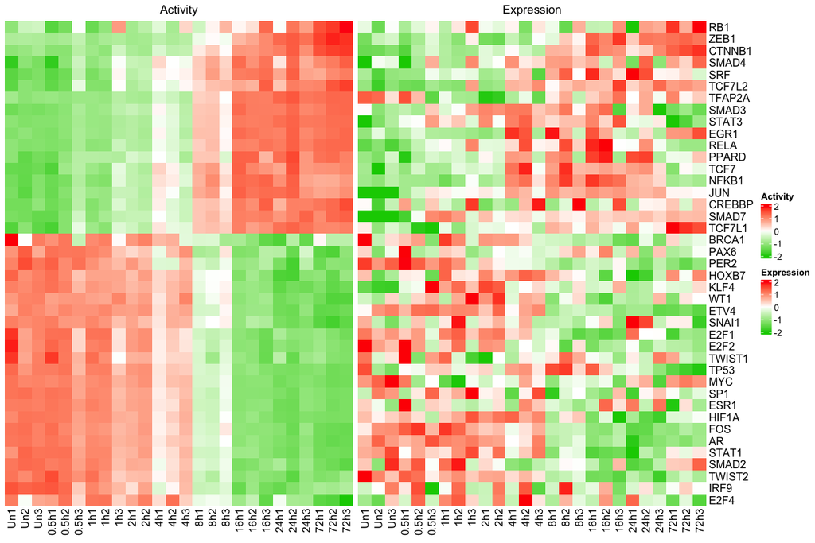

.

## 2.5 filter links

After calculating the TFs’ activities, we filter the link relations based on mutual information and entropy. A dynamic illustration of the network can be found **here**

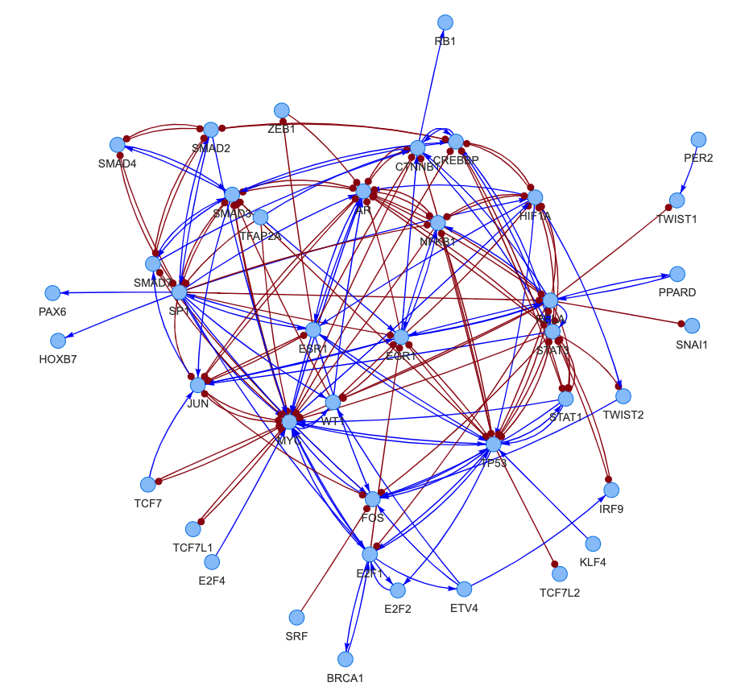

```r
tf_links = TF_Filter(acts_mat, hDB, miTh = .05, nbins = 8, corMethod = "spearman", DPI = T)
cor(acts_mat["CTNNB1",], acts_mat["ZEB1",], method = "spearman")
dim(tf_links)
length(unique(c(tf_links$Source, tf_links$Target)))
unique(c(tf_links$Source, tf_links$Target))
"SNAI1" %in% unique(c(tf_links$Source, tf_links$Target))
plot_network_v(tf_links)
```

# 3 Fine-tuning of NetAct

One remaining question is to reconsider the grouping information of downstream genes for each TFs. Previously, the calculation is based on the unsupervised clustering of the downstream gene expressions and partitioning into two groups. However, it ignores the activiation and inhibition (+/-) schemes. Here, we provide the strategy for fine-tune this effect.

## 3.1 find the DE genes and targets

In this section, we will find the DE-to-DE relations.

```r
nodes = unique(c(tf_links$Source, tf_links$Target))
#idenify DEs and non DEs
non.DEGs = row.names(acts_mat)[row.names(acts_mat) %in% row.names(DErslt$Overall$table)[DErslt$Overall$table$adj.P.Val >= .05]]
non.in.net = non.DEGs[non.DEGs %in% nodes]
DEGs = row.names(acts_mat)[row.names(acts_mat) %in% row.names(DErslt$Overall$table)[DErslt$Overall$table$adj.P.Val < .05]]
de.in.net = DEGs[DEGs %in% nodes]
#identify DE and non DE targets
de.in.net.targets = vector(mode = "list", length = length(de.in.net))
for (i in 1:length(de.in.net)){
  de.in.net.targets[[i]] = names(act.me$all_list[de.in.net[[i]]][[1]])
}
names(de.in.net.targets) = de.in.net
```

## 3.2 find the non-DE genes and targets

In this section, we will find the nonDE-to-nonDE relations.

```r
non.in.net.targets = vector(mode = "list", length = length(non.in.net))
for (i in 1:length(non.in.net)){
  non.in.net.targets[[i]] = names(act.me$all_list[non.in.net[[i]]][[1]])
}
names(non.in.net.targets) = non.in.net
```

## 3.3 prepare the relation matrix

We create the **o.mat** and **P.mat** to store the regulatory relations.

```r
a = length(non.in.net)
b = length(de.in.net)
C = expand.grid(1:a, 1:b)
combos.vec = vector(length = nrow(C))
o.mat = as.data.frame(matrix(nrow = length(combos.vec), ncol = 10))
colnames(o.mat) = c("pair", "tf1.targets", "tf2.targets", "tf1.non", "tf2.non", "A","B","C","D", "P.value")
for (i in 1:nrow(C)){
  combos.vec[[i]] = paste(C[i,][[1]], C[i,][[2]], sep = " ")
}
P.mat = matrix(nrow = length(non.in.net), ncol = length(de.in.net))
rownames(P.mat) = non.in.net
colnames(P.mat) = de.in.net
ex.genes = names(act.me$all_list)
```

## 3.4 build up the relations

```r
for (i in 1:length(combos.vec)){
  tf1 <- non.in.net[[as.integer(strsplit(combos.vec[[i]], split = " ")[[1]][1])]]
  tf2 <-de.in.net[[as.integer(strsplit(combos.vec[[i]], split = " ")[[1]][2])]]
  o.mat[i,1] <- paste0(tf1, " and ", tf2)
  tf1.targets <- non.in.net.targets[[tf1]]
  tf2.targets <- de.in.net.targets[[tf2]]
  tf1.non <- setdiff(ex.genes, tf1.targets)
  tf2.non <- setdiff(ex.genes, tf2.targets)
  A <- length(intersect(tf1.targets, tf2.targets))
  B <- length(intersect(tf1.targets, tf2.non))
  C <- length(intersect(tf1.non, tf2.targets))
  D <- length(intersect(tf1.non, tf2.non))
  fish.mat <- matrix(c(A,C,B,D), nrow = 2, ncol=2)
  #fish <- fisher.test(fish.mat)
  fish <- fisher.test(fish.mat, alternative = "greater")
  #fish <- fisher.test(fish.mat, alternative = "less")
  o.mat[i,2] <- length(tf1.targets)
  o.mat[i,3] <- length(tf2.targets)
  o.mat[i,4] <- length(tf1.non)
  o.mat[i,5] <- length(tf2.non)
  o.mat[i,6] <- A
  o.mat[i,7] <- B
  o.mat[i,8] <- C
  o.mat[i,9] <- D
  o.mat[i,10] <- fish$p.value
  P.mat[tf1,tf2] <- fish$p.value
}
```

# Reference

Han, Heonjong, Hongseok Shim, Donghyun Shin, Jung Eun Shim, Yunhee Ko, Junha Shin, Hanhae Kim, et al. 2015. “TRRUST: A Reference Database of Human Transcriptional Regulatory Interactions.” *Scientific Reports* 5 (1): 1–11.

Liu, Zhi-Ping, Canglin Wu, Hongyu Miao, and Hulin Wu. 2015. “RegNetwork: An Integrated Database of Transcriptional and Post-Transcriptional Regulatory Networks in Human and Mouse.” *Database* 2015.

Sartor, Maureen A, Vasudeva Mahavisno, Venkateshwar G Keshamouni, James Cavalcoli, Zachary Wright, Alla Karnovsky, Rork Kuick, et al. 2010. “ConceptGen: A Gene Set Enrichment and Gene Set Relation Mapping Tool.” *Bioinformatics* 26 (4): 456–63.

Zhao, Fang, Zhenyu Xuan, Lihua Liu, and Michael Q Zhang. 2005. “TRED: A Transcriptional Regulatory Element Database and a Platform for in Silico Gene Regulation Studies.” *Nucleic Acids Research* 33 (suppl_1): D103–7.